# Assignment 6

Gabriela Serrano Echenagucia

2022 April 10

# **Classification Problem**

```r
# Load the dataset "breast-cancer-wisconsin.data"
BC = read.csv("~/Library/Mobile Documents/com~apple~CloudDocs/Desktop/Univ Miami/6th Semester - SPRING 2022/CSC 597/Assignments/Datasets/Classification/breast-cancer-wisconsin.data")

# Assign names ot the columns
colnames(BC) <- c("sample.num","clump.thickness","uniformity.size","uniformity.shape","marginal.adh","single.size","nuclei","chromatin","nucleoli","mitoses","tumor")

# Missing values are represented with '?' char. So, replace with NA
BC[BC == '?'] <- NA

# Omit missing values
BC = na.omit(BC)

# For some reason R was reading column 7 as class: "char". So, change everything to numeric
BC = as.data.frame(apply(BC, 2, as.numeric))

# Convert 2 and 4 to 0 and 1, respectively
# 2 = 0 = benign
BC$tumor[BC$tumor=="2"] <- 0
# 4 = 1 = malign
BC$tumor[BC$tumor=="4"] <- 1

# Convert tumor (classification variable) to a factor
BC$tumor <- as.factor(BC$tumor)

# We make sure that this is true: (0 = 0 = benign) and (1 = 1 = malign), for the predictions part
contrasts(BC$tumor)
```

```
  1
0 0
1 1
```

```r
# View(BC)
```

```r
# Set seed
set.seed(44)

# Import libraries
library(e1071)
library(caret)
library(ROCR)
```

## 1. Split the datasets using 80% for training and 20% for testing

```r
# Split
dt = sort(sample(nrow(BC), nrow(BC)*.8))
train = BC[dt,] # 545 obs out of 682 (or 80 %)
test = BC[-dt,] # 137 obs out of 682 (or 20 %)

# Training Set
train
```

|  | sample.num | clump.thickness | uniformity.size | uniformity.shape | marginal.adh | single.size | nuclei | chromatin | nucleoli | mitoses | tumor |
| --- | --- | --- | --- | --- | --- | --- | --- | --- | --- | --- | --- |
| 1 | 1002945 | 5 | 4 | 4 | 5 | 7 | 10 | 3 | 2 | 1 | 0 |
| 2 | 1015425 | 3 | 1 | 1 | 1 | 2 | 2 | 3 | 1 | 1 | 0 |
| 4 | 1017023 | 4 | 1 | 1 | 3 | 2 | 1 | 3 | 1 | 1 | 0 |
| 5 | 1017122 | 8 | 10 | 10 | 8 | 7 | 10 | 9 | 7 | 1 | 1 |
| 6 | 1018099 | 1 | 1 | 1 | 1 | 2 | 10 | 3 | 1 | 1 | 0 |
| 8 | 1033078 | 2 | 1 | 1 | 1 | 2 | 1 | 1 | 1 | 5 | 0 |
| 9 | 1033078 | 4 | 2 | 1 | 1 | 2 | 1 | 2 | 1 | 1 | 0 |
| 10 | 1035283 | 1 | 1 | 1 | 1 | 1 | 1 | 3 | 1 | 1 | 0 |
| 11 | 1036172 | 2 | 1 | 1 | 1 | 2 | 1 | 2 | 1 | 1 | 0 |
| 12 | 1041801 | 5 | 3 | 3 | 3 | 2 | 3 | 4 | 4 | 1 | 1 |

[output cut: 535 more lines]

```r
# Testing Set
test
```

|  | sample.num | clump.thickness | uniformity.size | uniformity.shape | marginal.adh | single.size | nuclei | chromatin | nucleoli | mitoses | tumor |
| --- | --- | --- | --- | --- | --- | --- | --- | --- | --- | --- | --- |
| 3 | 1016277 | 6 | 8 | 8 | 1 | 3 | 4 | 3 | 7 | 1 | 0 |
| 7 | 1018561 | 2 | 1 | 2 | 1 | 2 | 1 | 3 | 1 | 1 | 0 |
| 16 | 1048672 | 4 | 1 | 1 | 1 | 2 | 1 | 2 | 1 | 1 | 0 |
| 21 | 1054593 | 10 | 5 | 5 | 3 | 6 | 7 | 7 | 10 | 1 | 1 |
| 23 | 1059552 | 1 | 1 | 1 | 1 | 2 | 1 | 3 | 1 | 1 | 0 |
| 25 | 1066373 | 3 | 2 | 1 | 1 | 1 | 1 | 2 | 1 | 1 | 0 |
| 26 | 1066979 | 5 | 1 | 1 | 1 | 2 | 1 | 2 | 1 | 1 | 0 |
| 27 | 1067444 | 2 | 1 | 1 | 1 | 2 | 1 | 2 | 1 | 1 | 0 |
| 40 | 1100524 | 6 | 10 | 10 | 2 | 8 | 10 | 7 | 3 | 3 | 1 |
| 52 | 1110524 | 10 | 5 | 5 | 6 | 8 | 8 | 7 | 1 | 1 | 1 |

[output cut: 127 more lines]

## 2. Create an SVM model using a radial basis kernel

```r
svm.fitA = svm(tumor~., data=train, kernel="radial", gamma=1, cost=1)

?plot.svm
#plot(svm.fitA, train, clump.thickness~uniformity.size)

summary(svm.fitA)
```

```
Call:
svm(formula = tumor ~ ., data = train, kernel = "radial", gamma = 1, cost = 1)


Parameters:
   SVM-Type:  C-classification
 SVM-Kernel:  radial
       cost:  1

Number of Support Vectors:  272

 ( 81 191 )


Number of Classes:  2

Levels:
 0 1
```

### a. How does the model perform?

The SVM model created using a radial basis kernel (with gamma=1 and cost=1), performs quite good. If we look at the performance metrics and the main diagonal in the confusion matrix we can see that the number of correct predictions is greater than the number of mispredictions. There is indication of a high prediction accuracy with 126 correct predictions out of 137.

```r
# Testing the model on the test set (model A)
ypredA = predict(svm.fitA, test)
table(prediction=ypredA, reference=test$tumor)
```

```
          reference
prediction  0  1
         0 82  1
         1 10 44
```

### b. Tune the model using cross-validation. Print out the information about the best model

```r
# Tune
tune.out=tune(svm, tumor~., data=train, kernel="radial",
              ranges=list(cost=c(0.1,1,10,100,1000),gamma=c(0.5,1,2,3,4) ))
summary(tune.out)
```

```
Parameter tuning of ‘svm’:

- sampling method: 10-fold cross validation

- best parameters:
```

|  | cost | gamma |
| --- | --- | --- |
|  | 10 | 0.5 |

```
- best performance: 0.04040404

- Detailed performance results:
```

| cost | gamma | error | dispersion |
| --- | --- | --- | --- |
| 1e-01 | 0.5 | 0.05676768 | 0.04252661 |
| 1e+00 | 0.5 | 0.04222222 | 0.03582523 |
| 1e+01 | 0.5 | 0.04040404 | 0.03105846 |
| 1e+02 | 0.5 | 0.04040404 | 0.03105846 |
| 1e+03 | 0.5 | 0.04040404 | 0.03105846 |
| 1e-01 | 1.0 | 0.07686869 | 0.04516641 |
| 1e+00 | 1.0 | 0.05861953 | 0.04011477 |
| 1e+01 | 1.0 | 0.05494949 | 0.04215552 |
| 1e+02 | 1.0 | 0.05494949 | 0.04215552 |
| 1e+03 | 1.0 | 0.05494949 | 0.04215552 |

[output cut: 15 more lines]

```r
# Best model
summary(tune.out$best.model)
```

```
Call:
best.tune(method = svm, train.x = tumor ~ ., data = train, ranges = list(cost = c(0.1, 1, 10, 100,
    1000), gamma = c(0.5, 1, 2, 3, 4)), kernel = "radial")


Parameters:
   SVM-Type:  C-classification
 SVM-Kernel:  radial
       cost:  10

Number of Support Vectors:  224

 ( 51 173 )


Number of Classes:  2

Levels:
 0 1
```

```r
# Model B
svm.fitB = svm(tumor~., data=train, kernel="radial", gamma=0.5, cost=10)

#plot(svm.fitB, train, clump.thickness~uniformity.size)

summary(svm.fitB)
```

```
Call:
svm(formula = tumor ~ ., data = train, kernel = "radial", gamma = 0.5, cost = 10)


Parameters:
   SVM-Type:  C-classification
 SVM-Kernel:  radial
       cost:  10

Number of Support Vectors:  224

 ( 51 173 )


Number of Classes:  2

Levels:
 0 1
```

### c. Compare the models in “a” and “b”

By tuning Model A (SVM, radial kernel with gamma=1 and cost=1), we were able to slightly improve the results. Again, by looking at the main diagonal in the confusion matrix we can see good results. Model B (tuned) was able to make 129 correct predictions out of 137, by using optimal parameters (gamma=0.5 and cost=10). The performance metrics we got from running the confusionMatrix function indicate an accuracy of approximately 92% for Model A and around 94% for Model B (Model A, but tuned).

```r
# Testing the model on the test set (model B)

  # Model A
  confusionMatrix(ypredA, test$tumor)
```

```
Confusion Matrix and Statistics

          Reference
Prediction  0  1
         0 82  1
         1 10 44

               Accuracy : 0.9197
                 95% CI : (0.8609, 0.9592)
    No Information Rate : 0.6715
    P-Value [Acc > NIR] : 4.994e-12

                  Kappa : 0.8268

 Mcnemar's Test P-Value : 0.01586

            Sensitivity : 0.8913
            Specificity : 0.9778
         Pos Pred Value : 0.9880
         Neg Pred Value : 0.8148
             Prevalence : 0.6715
         Detection Rate : 0.5985
   Detection Prevalence : 0.6058
      Balanced Accuracy : 0.9345

       'Positive' Class : 0
```

```r
  # Model B
  ypredB = predict(svm.fitB, test)
  confusionMatrix(ypredB, test$tumor)
```

```
Confusion Matrix and Statistics

          Reference
Prediction  0  1
         0 85  1
         1  7 44

               Accuracy : 0.9416
                 95% CI : (0.8882, 0.9745)
    No Information Rate : 0.6715
    P-Value [Acc > NIR] : 1.9e-14

                  Kappa : 0.872

 Mcnemar's Test P-Value : 0.0771

            Sensitivity : 0.9239
            Specificity : 0.9778
         Pos Pred Value : 0.9884
         Neg Pred Value : 0.8627
             Prevalence : 0.6715
         Detection Rate : 0.6204
   Detection Prevalence : 0.6277
      Balanced Accuracy : 0.9508

       'Positive' Class : 0
```

## 3. Compare the performance of the different models built.

### a. Plot ROC curves for the SVM model

```r
# ROC function
rocplot = function(pred, truth, ...){
  predob = prediction(pred, truth)
  perf = performance(predob,"fpr", "tpr")
  plot(perf,...)
  }
```

#### Model A

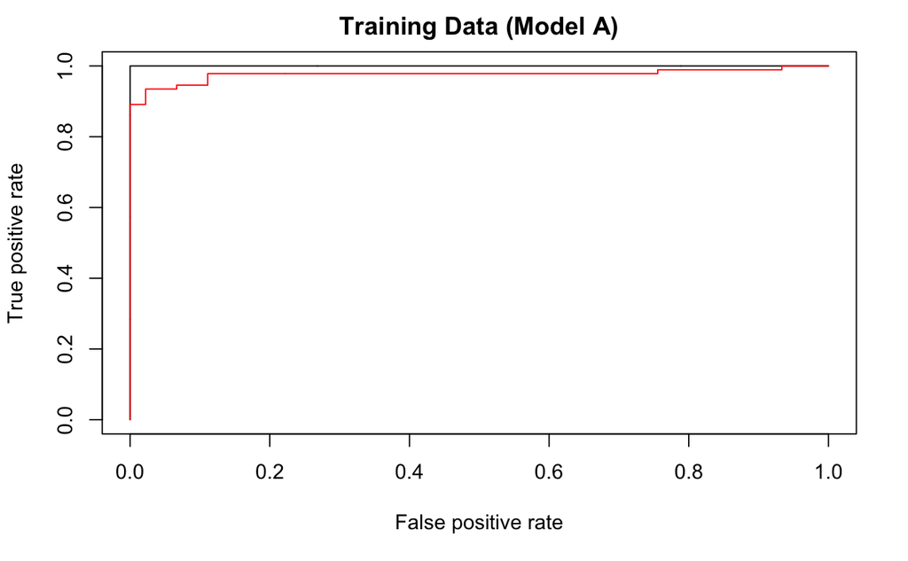

```r
# Model A
svmfit.A = svm(tumor~., data=train, kernel="radial", gamma=1, cost=1, decision.values=T)
fitted.A = attributes(predict(svmfit.A, train, decision.values=T))$decision.values

# Plot ROC curve
rocplot(fitted.A, train$tumor, main="Training Data (Model A)", xlab="False positive rate", ylab="True positive rate")

# Performance on test data
fitted.tA = attributes(predict(svmfit.A, test, decision.values=T))$decision.values
rocplot(fitted.tA, test$tumor, main="Test Data (Model A)", add=T, col="red")
```

#### Model B

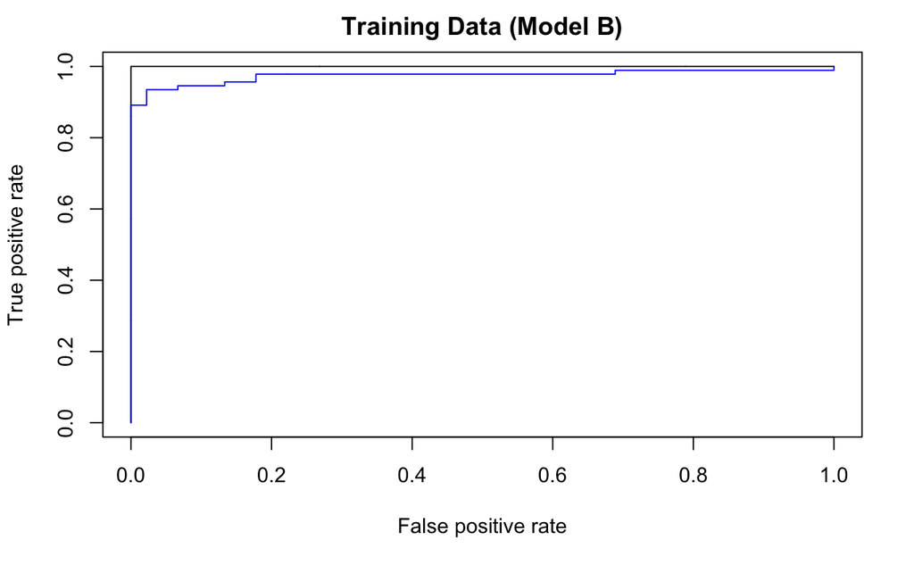

```r
# Model B
svmfit.B = svm(tumor~., data=train, kernel="radial", gamma=0.5, cost=10, decision.values=T)
fitted.B = attributes(predict(svmfit.B, train, decision.values=T))$decision.values

# Plot ROC curve
rocplot(fitted.B, train$tumor, main="Training Data (Model B)", xlab="False positive rate", ylab="True positive rate")

# Performance on test data
fitted.tB = attributes(predict(svmfit.B, test, decision.values=T))$decision.values
rocplot(fitted.tB, test$tumor, main="Test Data (Model B)", add=T,col="blue")
```